# Statistics for quantitative mass spectrometry - Day 2

Section 4 : Working with Limma, DESeq

Meena Choi

5/9/2017

## Objective

- Compare the results with different statistical methods.
- Significance analysis for MS proteomics based peak count data

## Data

- the quantified peak intensities data from ABRF 2015, processed by Skyline.
- the spectral count data from ABRF 2015 is used.

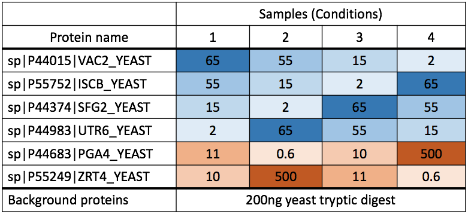

Summary of the ABRF 2015 study design, Choi, et al. J Proteome Res. 2017

# 1. Example codes for using Limma

We can use `Limma` package, which is popular for microarray datasets. This is for differenrential protein analysis. W need protein-level quantified intensities. Let’s use the `$RunlevelData` from `dataProcess` function.

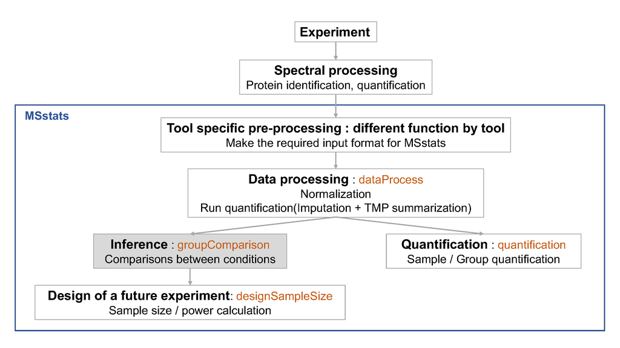

## 1.1 Load the package, `Limma`

`Limma` is available in Bioconductor.

```r
library(limma)
## Let's load reshape2 function
library(reshape2)
```

## 1.2 Load the processed Skyline data and reformat

Let’s load the processed by `dataProcess` function in MSstats from section 2.

```r
load(file='./data_Skyline/quant.skyline.rda')
```

We will use run-level summarized data for hypothesis testing.

```r
## use run-level summarized value from MSstats
input <- quant.skyline$RunlevelData
head(input)
```

```
##   RUN              Protein LogIntensities NumMeasuredFeature
## 1   1 sp|D6VTK4|STE2_YEAST       26.81232                  8
## 2   2 sp|D6VTK4|STE2_YEAST       26.60786                  8
## 3   3 sp|D6VTK4|STE2_YEAST       26.58301                  8
## 4   4 sp|D6VTK4|STE2_YEAST       26.83563                  8
## 5   5 sp|D6VTK4|STE2_YEAST       26.79430                  8
## 6   6 sp|D6VTK4|STE2_YEAST       26.60863                  8
##   MissingPercentage more50missing NumImputedFeature
## 1                 0         FALSE                 0
## 2                 0         FALSE                 0
## 3                 0         FALSE                 0
## 4                 0         FALSE                 0
## 5                 0         FALSE                 0
## 6                 0         FALSE                 0
##                 originalRUN GROUP GROUP_ORIGINAL SUBJECT_ORIGINAL
## 1 JD_06232014_sample1_B.raw     1     Condition1                1
## 2 JD_06232014_sample1_C.raw     1     Condition1                1
## 3 JD_06232014_sample1-A.raw     1     Condition1                1
## 4 JD_06232014_sample2_A.raw     2     Condition2                2
## 5 JD_06232014_sample2_B.raw     2     Condition2                2
## 6 JD_06232014_sample2_C.raw     2     Condition2                2
##   SUBJECT_NESTED SUBJECT
## 1            1.1       1
## 2            1.1       1
## 3            1.1       1
## 4            2.2       2
## 5            2.2       2
## 6            2.2       2
```

`input` is the long format data. But, we need the wide format data for `Limma`.

```r
## Make the wide format data
input.wide <- dcast(Protein ~ originalRUN, data=input, value.var = 'LogIntensities')
head(input.wide)
```

```
##                 Protein JD_06232014_sample1_B.raw
## 1  sp|D6VTK4|STE2_YEAST                  26.81232
## 2  sp|O13297|CET1_YEAST                  24.71912
## 3  sp|O13329|FOB1_YEAST                  23.37678
## 4  sp|O13539|THP2_YEAST                  27.52021
## 5 sp|O13547|CCW14_YEAST                  27.22234
## 6 sp|O13563|RPN13_YEAST                  26.09476
##   JD_06232014_sample1_C.raw JD_06232014_sample1-A.raw
## 1                  26.60786                  26.58301
## 2                  24.67437                  24.71809
## 3                  24.01464                  23.47075
## 4                  27.38510                  24.29661
## 5                  26.80454                  27.11638
## 6                  26.29253                  26.17056
##   JD_06232014_sample2_A.raw JD_06232014_sample2_B.raw
```

[output cut: 34 more lines]

```r
## annotate protein id in rowname.
rownames(input.wide) <- input.wide$Protein
input.wide <- input.wide[, -1]
head(input.wide)
```

```
##                       JD_06232014_sample1_B.raw JD_06232014_sample1_C.raw
## sp|D6VTK4|STE2_YEAST                   26.81232                  26.60786
## sp|O13297|CET1_YEAST                   24.71912                  24.67437
## sp|O13329|FOB1_YEAST                   23.37678                  24.01464
## sp|O13539|THP2_YEAST                   27.52021                  27.38510
## sp|O13547|CCW14_YEAST                  27.22234                  26.80454
## sp|O13563|RPN13_YEAST                  26.09476                  26.29253
##                       JD_06232014_sample1-A.raw JD_06232014_sample2_A.raw
## sp|D6VTK4|STE2_YEAST                   26.58301                  26.83563
## sp|O13297|CET1_YEAST                   24.71809                  24.52341
## sp|O13329|FOB1_YEAST                   23.47075                  23.17165
## sp|O13539|THP2_YEAST                   24.29661                  25.88066
## sp|O13547|CCW14_YEAST                  27.11638                  27.17386
## sp|O13563|RPN13_YEAST                  26.17056                  25.90882
##                       JD_06232014_sample2_B.raw JD_06232014_sample2_C.raw
## sp|D6VTK4|STE2_YEAST                   26.79430                  26.60863
## sp|O13297|CET1_YEAST                   24.67593                  24.57865
## sp|O13329|FOB1_YEAST                   23.43427                  23.76997
## sp|O13539|THP2_YEAST                   26.10254                  25.90646
## sp|O13547|CCW14_YEAST                  26.91302                  26.88314
## sp|O13563|RPN13_YEAST                  26.12989                  26.01078
##                       JD_06232014_sample3_A.raw JD_06232014_sample3_B.raw
## sp|D6VTK4|STE2_YEAST                   26.62966                  26.49626
## sp|O13297|CET1_YEAST                   24.38955                  24.62652
## sp|O13329|FOB1_YEAST                   24.20100                  23.28643
## sp|O13539|THP2_YEAST                   25.65002                  26.33853
## sp|O13547|CCW14_YEAST                  26.56416                  26.75541
## sp|O13563|RPN13_YEAST                  26.17791                  26.03753
##                       JD_06232014_sample3_C.raw JD_06232014_sample4_B.raw
## sp|D6VTK4|STE2_YEAST                   26.53029                  26.60612
## sp|O13297|CET1_YEAST                   24.66197                  24.64886
## sp|O13329|FOB1_YEAST                   23.73741                  23.16646
## sp|O13539|THP2_YEAST                   25.91799                  26.70101
## sp|O13547|CCW14_YEAST                  26.95027                  26.98082
## sp|O13563|RPN13_YEAST                  26.11412                  26.07538
##                       JD_06232014_sample4_C.raw JD_06232014_sample4-A.raw
## sp|D6VTK4|STE2_YEAST                   26.38611                  26.65573
## sp|O13297|CET1_YEAST                   24.66559                  24.50814
## sp|O13329|FOB1_YEAST                   23.60780                  23.03473
## sp|O13539|THP2_YEAST                   25.91781                  25.07576
## sp|O13547|CCW14_YEAST                  26.80274                  27.07526
## sp|O13563|RPN13_YEAST                  26.05415                  25.77958
```

## 1.3 Set comparison matrix

Then, we need to annotate group information for each run.

```r
design <- model.matrix(~0+factor(c(1,1,1,2,2,2,3,3,3,4,4,4)))
colnames(design) <- c('Condition1', 'Condition2', 'Condition3', 'Condition4')
design
```

```
##    Condition1 Condition2 Condition3 Condition4
## 1           1          0          0          0
## 2           1          0          0          0
## 3           1          0          0          0
## 4           0          1          0          0
## 5           0          1          0          0
## 6           0          1          0          0
## 7           0          0          1          0
## 8           0          0          1          0
## 9           0          0          1          0
## 10          0          0          0          1
## 11          0          0          0          1
## 12          0          0          0          1
## attr(,"assign")
## [1] 1 1 1 1
## attr(,"contrasts")
## attr(,"contrasts")$`factor(c(1, 1, 1, 2, 2, 2, 3, 3, 3, 4, 4, 4))`
## [1] "contr.treatment"
```

Let’s set up what comparisons you want. Try for 3 comparisons, Condition2 vs Condition1, Condition3 vs Condition1, Condition4 vs Condition1.

```r
contrast.matrix <- makeContrasts(Condition2-Condition1,
                                 Condition3-Condition1,
                                 Condition4-Condition1,
                                 levels=design)
contrast.matrix
```

```
##             Contrasts
## Levels       Condition2 - Condition1 Condition3 - Condition1
##   Condition1                      -1                      -1
##   Condition2                       1                       0
##   Condition3                       0                       1
##   Condition4                       0                       0
##             Contrasts
## Levels       Condition4 - Condition1
##   Condition1                      -1
##   Condition2                       0
##   Condition3                       0
##   Condition4                       1
```

## 1.4. Compare between groups

Fit linear model for each protein.

```r
fit <- lmFit(input.wide, design)
class(fit)
```

```
## [1] "MArrayLM"
## attr(,"package")
## [1] "limma"
```

```r
names(fit)
```

```
##  [1] "coefficients"     "stdev.unscaled"   "sigma"
##  [4] "df.residual"      "cov.coefficients" "pivot"
##  [7] "rank"             "Amean"            "method"
## [10] "design"
```

```r
fit
```

```
## An object of class "MArrayLM"
## $coefficients
##                       Condition1 Condition2 Condition3 Condition4
## sp|D6VTK4|STE2_YEAST    26.66773   26.74619   26.55207   26.54932
## sp|O13297|CET1_YEAST    24.70386   24.59266   24.55935   24.60753
## sp|O13329|FOB1_YEAST    23.62073   23.45863   23.74161   23.26966
## sp|O13539|THP2_YEAST    26.40064   25.96322   25.96885   25.89819
## sp|O13547|CCW14_YEAST   27.04775   26.99001   26.75661   26.95294
## 3022 more rows ...
##
## $stdev.unscaled
##                       Condition1 Condition2 Condition3 Condition4
## sp|D6VTK4|STE2_YEAST   0.5773503  0.5773503  0.5773503  0.5773503
## sp|O13297|CET1_YEAST   0.5773503  0.5773503  0.5773503  0.5773503
## sp|O13329|FOB1_YEAST   0.5773503  0.5773503  0.5773503  0.5773503
## sp|O13539|THP2_YEAST   0.5773503  0.5773503  0.5773503  0.5773503
## sp|O13547|CCW14_YEAST  0.5773503  0.5773503  0.5773503  0.5773503
## 3022 more rows ...
##
## $sigma
## [1] 0.11816348 0.09490955 0.35627933 1.01496262 0.17969953
## 3022 more elements ...
##
## $df.residual
## [1] 8 8 8 8 8
## 3022 more elements ...
##
## $cov.coefficients
##            Condition1 Condition2 Condition3 Condition4
## Condition1  0.3333333  0.0000000  0.0000000  0.0000000
## Condition2  0.0000000  0.3333333  0.0000000  0.0000000
## Condition3  0.0000000  0.0000000  0.3333333  0.0000000
## Condition4  0.0000000  0.0000000  0.0000000  0.3333333
##
## $pivot
## [1] 1 2 3 4
##
## $rank
## [1] 4
##
## $Amean
##  sp|D6VTK4|STE2_YEAST  sp|O13297|CET1_YEAST  sp|O13329|FOB1_YEAST
##              26.62883              24.61585              23.52266
##  sp|O13539|THP2_YEAST sp|O13547|CCW14_YEAST
##              26.05773              26.93683
## 3022 more elements ...
##
## $method
## [1] "ls"
##
## $design
##   Condition1 Condition2 Condition3 Condition4
## 1          1          0          0          0
## 2          1          0          0          0
## 3          1          0          0          0
## 4          0          1          0          0
## 5          0          1          0          0
## 7 more rows ...
```

Given a linear model fit, compute estimated coefficients and standard errors for a given set of contrasts

```r
fit2 <- contrasts.fit(fit, contrast.matrix)
```

Given a linear model fit, compute moderated t-statistics, moderated F-statistic, and log-odds of differential abundance by empirical Bayes moderation of the standard errors.

```r
fit3 <- eBayes(fit2)
fit3
```

```
## An object of class "MArrayLM"
## $coefficients
##                        Contrasts
##                         Condition2 - Condition1 Condition3 - Condition1
##   sp|D6VTK4|STE2_YEAST               0.07846162              -0.1156552
##   sp|O13297|CET1_YEAST              -0.11119732              -0.1445104
##   sp|O13329|FOB1_YEAST              -0.16209422               0.1208883
##   sp|O13539|THP2_YEAST              -0.43742107              -0.4317962
##   sp|O13547|CCW14_YEAST             -0.05774773              -0.2911415
##                        Contrasts
##                         Condition4 - Condition1
##   sp|D6VTK4|STE2_YEAST              -0.11840650
##   sp|O13297|CET1_YEAST              -0.09632625
##   sp|O13329|FOB1_YEAST              -0.35106152
##   sp|O13539|THP2_YEAST              -0.50244849
##   sp|O13547|CCW14_YEAST             -0.09481687
## 3022 more rows ...
##
## $stdev.unscaled
##                        Contrasts
##                         Condition2 - Condition1 Condition3 - Condition1
##   sp|D6VTK4|STE2_YEAST                0.8164966               0.8164966
##   sp|O13297|CET1_YEAST                0.8164966               0.8164966
##   sp|O13329|FOB1_YEAST                0.8164966               0.8164966
##   sp|O13539|THP2_YEAST                0.8164966               0.8164966
##   sp|O13547|CCW14_YEAST               0.8164966               0.8164966
##                        Contrasts
##                         Condition4 - Condition1
##   sp|D6VTK4|STE2_YEAST                0.8164966
##   sp|O13297|CET1_YEAST                0.8164966
##   sp|O13329|FOB1_YEAST                0.8164966
##   sp|O13539|THP2_YEAST                0.8164966
##   sp|O13547|CCW14_YEAST               0.8164966
## 3022 more rows ...
##
## $sigma
## [1] 0.11816348 0.09490955 0.35627933 1.01496262 0.17969953
## 3022 more elements ...
##
## $df.residual
```

[output cut: 114 more lines]

```
##                         Condition4 - Condition1
##   sp|D6VTK4|STE2_YEAST                -5.961303
##   sp|O13297|CET1_YEAST                -5.999530
##   sp|O13329|FOB1_YEAST                -5.877597
##   sp|O13539|THP2_YEAST                -6.505159
##   sp|O13547|CCW14_YEAST               -6.491884
## 3022 more rows ...
##
## $F
## [1] 2.0214866 1.2148305 1.1733904 0.1870824 1.6637427
## 3022 more elements ...
##
## $F.p.value
## [1] 0.1769197 0.3558345 0.3695444 0.9027004 0.2389981
## 3022 more elements ...
```

```r
class(fit3)
```

```
## [1] "MArrayLM"
## attr(,"package")
## [1] "limma"
```

```r
names(fit3)
```

```
##  [1] "coefficients"     "stdev.unscaled"   "sigma"
##  [4] "df.residual"      "cov.coefficients" "rank"
##  [7] "Amean"            "method"           "design"
## [10] "contrasts"        "df.prior"         "s2.prior"
## [13] "var.prior"        "proportion"       "s2.post"
## [16] "t"                "df.total"         "p.value"
## [19] "lods"             "F"                "F.p.value"
```

## 1.5 Reformat the output

Let’s make the table with result.

```r
log2FC <- melt(fit3$coefficients)
head(log2FC)
```

```
##                    Var1               Contrasts       value
## 1  sp|D6VTK4|STE2_YEAST Condition2 - Condition1  0.07846162
## 2  sp|O13297|CET1_YEAST Condition2 - Condition1 -0.11119732
## 3  sp|O13329|FOB1_YEAST Condition2 - Condition1 -0.16209422
## 4  sp|O13539|THP2_YEAST Condition2 - Condition1 -0.43742107
## 5 sp|O13547|CCW14_YEAST Condition2 - Condition1 -0.05774773
## 6 sp|O13563|RPN13_YEAST Condition2 - Condition1 -0.16945187
```

```r
colnames(log2FC) <- c('Protein', 'Label', 'log2FC')

pvalue <- melt(fit3$p.value)
head(pvalue)
```

```
##                    Var1               Contrasts     value
## 1  sp|D6VTK4|STE2_YEAST Condition2 - Condition1 0.4298539
## 2  sp|O13297|CET1_YEAST Condition2 - Condition1 0.1936459
## 3  sp|O13329|FOB1_YEAST Condition2 - Condition1 0.5580689
## 4  sp|O13539|THP2_YEAST Condition2 - Condition1 0.5754886
## 5 sp|O13547|CCW14_YEAST Condition2 - Condition1 0.6858158
## 6 sp|O13563|RPN13_YEAST Condition2 - Condition1 0.1031135
```

```r
colnames(pvalue) <- c('Protein', 'Label', 'pvalue')

test.limma <- merge(log2FC, pvalue, by=c('Protein', 'Label'))
head(test.limma)
```

```
##                Protein                   Label      log2FC    pvalue
## 1 sp|D6VTK4|STE2_YEAST Condition2 - Condition1  0.07846162 0.4298539
## 2 sp|D6VTK4|STE2_YEAST Condition3 - Condition1 -0.11565524 0.2534049
## 3 sp|D6VTK4|STE2_YEAST Condition4 - Condition1 -0.11840650 0.2430473
## 4 sp|O13297|CET1_YEAST Condition2 - Condition1 -0.11119732 0.1936459
## 5 sp|O13297|CET1_YEAST Condition3 - Condition1 -0.14451041 0.1005301
## 6 sp|O13297|CET1_YEAST Condition4 - Condition1 -0.09632625 0.2549654
```

## 1.6. Calculate adjusted p-value

```r
adj.pvalue <- sapply(split(test.limma$pvalue, test.limma$Label),
                                function(x)p.adjust(x, method='BH'))
head(adj.pvalue)
```

```
##      Condition2 - Condition1 Condition3 - Condition1
## [1,]               0.9989843               0.7425607
## [2,]               0.9989843               0.6473947
## [3,]               0.9989843               0.8995063
## [4,]               0.9989843               0.8731474
## [5,]               0.9989843               0.6185299
## [6,]               0.9989843               0.8254341
##      Condition4 - Condition1
## [1,]               0.8021955
## [2,]               0.8112025
## [3,]               0.7850719
## [4,]               0.9458118
## [5,]               0.9420349
## [6,]               0.6716121
```

```r
rownames(adj.pvalue) <- unique(test.limma$Protein)
out <- melt(adj.pvalue)
head(out)
```

```
##                    Var1                    Var2     value
## 1  sp|D6VTK4|STE2_YEAST Condition2 - Condition1 0.9989843
## 2  sp|O13297|CET1_YEAST Condition2 - Condition1 0.9989843
## 3  sp|O13329|FOB1_YEAST Condition2 - Condition1 0.9989843
## 4  sp|O13539|THP2_YEAST Condition2 - Condition1 0.9989843
## 5 sp|O13547|CCW14_YEAST Condition2 - Condition1 0.9989843
## 6 sp|O13563|RPN13_YEAST Condition2 - Condition1 0.9989843
```

```r
colnames(out) <- c('Protein', 'Label', 'adj.pvalue')

test.limma <- merge(test.limma, out, by=c('Protein', 'Label'))
head(test.limma)
```

```
##                Protein                   Label      log2FC    pvalue
## 1 sp|D6VTK4|STE2_YEAST Condition2 - Condition1  0.07846162 0.4298539
## 2 sp|D6VTK4|STE2_YEAST Condition3 - Condition1 -0.11565524 0.2534049
## 3 sp|D6VTK4|STE2_YEAST Condition4 - Condition1 -0.11840650 0.2430473
## 4 sp|O13297|CET1_YEAST Condition2 - Condition1 -0.11119732 0.1936459
## 5 sp|O13297|CET1_YEAST Condition3 - Condition1 -0.14451041 0.1005301
## 6 sp|O13297|CET1_YEAST Condition4 - Condition1 -0.09632625 0.2549654
##   adj.pvalue
## 1  0.9989843
## 2  0.7425607
## 3  0.8021955
## 4  0.9989843
## 5  0.6473947
## 6  0.8112025
```

```r
save(test.limma, file='./data_Skyline/test.limma.rda')
write.csv(test.limma, file='./data_Skyline/test.limma.csv')
```

Let’s draw the volcano plot

```r
library(MSstats)
```

```r
## small trick to use the same volcano plot.
test.limma$issue <- NA

groupComparisonPlots(data=test.limma,
                     type='Volcanoplot',
                     address='Skyline_VolcanoPlot_limma_')
```

### Challenge

> 1. Compare the volcano plots from Limma and from MSstats (under ./backup/data_Skyline/testResult_ABRF_skyline_VolcanoPlot.pdf)
> 2. Repeat for different comparison matrix, including Condition3-Condition2, Condition4-Condition2, Condition4-Condition3.

```r
contrast.matrix <- makeContrasts(Condition3-Condition2,
                                 Condition4-Condition2,
                                 Condition4-Condition3,
                                 levels=design)
contrast.matrix
```

```
##             Contrasts
## Levels       Condition3 - Condition2 Condition4 - Condition2
##   Condition1                       0                       0
##   Condition2                      -1                      -1
##   Condition3                       1                       0
##   Condition4                       0                       1
##             Contrasts
## Levels       Condition4 - Condition3
##   Condition1                       0
##   Condition2                       0
##   Condition3                      -1
##   Condition4                       1
```

```r
fit <- lmFit(input.wide, design)
fit2 <- contrasts.fit(fit, contrast.matrix)
fit3 <- eBayes(fit2)
```